# 1. Read in acci.txt file from the course web site. Plot the time series. Take difference with lag 12. Plot the differenced data. Call it D2.

#### 1. Read in acci.txt file from the course web site. Plot the time series. Take difference with lag 12. Plot the differenced data. Call it D2.

```r
acci <- read.table("acci.txt", header = TRUE)
D1 <- ts(acci, frequency = 12)
D2 <- diff(D1, d = 12)
```

[output not shown]

```r
pp.test(D2)
```

```
##
##  Phillips-Perron Unit Root Test
##
## data:  D2
## Dickey-Fuller Z(alpha) = -105.5, Truncation lag parameter = 3,
## p-value = 0.01
## alternative hypothesis: stationary
```

```r
kpss.test(D2)
```

```
##
##  KPSS Test for Level Stationarity
##
## data:  D2
## KPSS Level = 0.0483, Truncation lag parameter = 1, p-value = 0.1
```

[figure not shown]

```r
layout(matrix(c(1, 1, 2, 3), 2, 2, byrow = TRUE))
```

#### 2. Fit D2 with linear trend using OLS. Is the slope significant? How did you determine? Can the output from the screen be trusted?

```r
time <- 1:length(D2)
(err_mod <- summary(lm_D2 <- lm(D2 ~ time)))
```

```
##
## Call:
## lm(formula = D2 ~ time)
##
## Residuals:
##      Min       1Q   Median       3Q      Max
## -1245097  -504589    21005   486720  1194118
##
## Coefficients:
##             Estimate Std. Error t value Pr(>|t|)
## (Intercept)    14854     159786    0.09     0.93
## time            -663       4556   -0.15     0.88
##
## Residual standard error: 611000 on 58 degrees of freedom
## Multiple R-squared:  0.000365,   Adjusted R-squared:  -0.0169
## F-statistic: 0.0212 on 1 and 58 DF,  p-value: 0.885
```

```r
resid <- lm_D2$residuals

(arima_mdl <- auto.arima(ts(resid, start = c(2, 1), freq = 12)))
```

```
## Series: ts(resid, start = c(2, 1), freq = 12)
## ARIMA(4,0,0)(0,1,1)[12] with drift
##
## Coefficients:
##          ar1     ar2     ar3     ar4    sma1   drift
##       -2.965  -3.879  -2.629  -0.779  -0.397  659.77
## s.e.   0.087   0.204   0.202   0.083   0.224   28.18
##
## sigma^2 estimated as 1.06e+09:  log likelihood=-425.1
## AIC=864.2   AICc=867   BIC=877.4
```

```r
adf.test(resid)
```

```
##
##  Augmented Dickey-Fuller Test
##
## data:  resid
## Dickey-Fuller = -19.95, Lag order = 3, p-value = 0.01
## alternative hypothesis: stationary
```

```r
pp.test(resid)
```

```
##
##  Phillips-Perron Unit Root Test
##
## data:  resid
## Dickey-Fuller Z(alpha) = -105.5, Truncation lag parameter = 3,
## p-value = 0.01
## alternative hypothesis: stationary
```

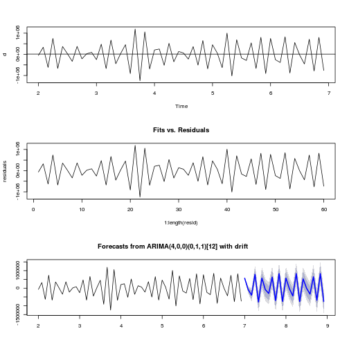

```r
layout(matrix(c(1, 2, 3), 3, 1, byrow = TRUE))
plot(D2)
abline(lm_D2)
plot(x = 1:length(resid), y = resid, type = "l", main = "Fits vs. Residuals",
    ylab = "residuals")
plot(forecast(arima_mdl))
```

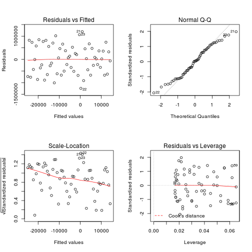

```r
layout(matrix(c(1, 2, 3, 4), 2, 2, byrow = TRUE))
plot(lm_D2)
```

#### 3. Fit residuals from (2) with seasonal ARIMA with d=0, D=0. (i.e. ARIMA(p,0,q)x(P,0,Q)12). Is the seasonal part necessary?

```r
(arima00 <- auto.arima(ts(lm_D2$residuals, start = c(2, 1), freq = 12), d = 0,
    D = 0))
```

```
## Series: ts(lm_D2$residuals, start = c(2, 1), freq = 12)
## ARIMA(3,0,0)(1,0,0)[12] with zero mean
##
## Coefficients:
##          ar1     ar2     ar3   sar1
##       -2.168  -1.869  -0.623  0.782
## s.e.   0.096   0.170   0.100  0.081
##
## sigma^2 estimated as 4.82e+09:  log likelihood=-762.4
## AIC=1535   AICc=1536   BIC=1545
```

Based on the results above, the standard error for the seasonal component is significant and therefore should be included in the forecast.

#### 4. Using the best model from #3, predict twelve months ahead in D2.

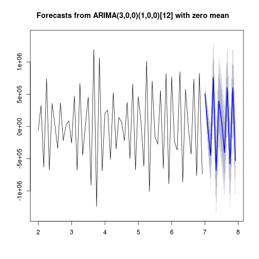

```r
plot(forecast(arima00, h = 12))
```

#### 5. Using the prediction from #4, predict twelve months ahead in D1 (original TS).

```r
(q5D1 <- Arima(D1, order = c(3, 0, 0), seasonal = list(order = c(1, 0, 0), period = 12)))
```

```
## Series: D1
## ARIMA(3,0,0)(1,0,0)[12] with non-zero mean
##
## Coefficients:
##         ar1    ar2    ar3   sar1  intercept
##       0.644  0.109  0.050  0.876     9317.0
## s.e.  0.124  0.140  0.126  0.049      915.4
##
## sigma^2 estimated as 121442:  log likelihood=-532.9
## AIC=1078   AICc=1079   BIC=1092
```

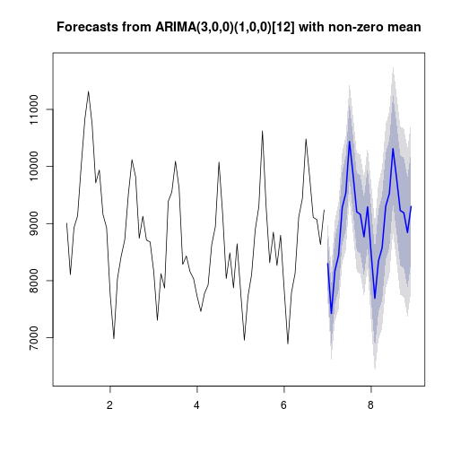

```r
q5 <- forecast(q5D1)
plot(q5)
```

#### 6. Using your model from In-class Ex2-#2, (ARIMA(p,1,q)x(P,1,Q)12 model), predict twelve months ahead in D1.

```r
(q6D1 <- auto.arima(D1, d = 1, D = 1))
```

```
## Series: D1
## ARIMA(0,1,1)(0,1,1)[12]
##
## Coefficients:
##          ma1    sma1
##       -0.426  -0.558
## s.e.   0.123   0.179
##
## sigma^2 estimated as 99480:  log likelihood=-425.5
## AIC=857.1   AICc=857.5   BIC=863.3
```

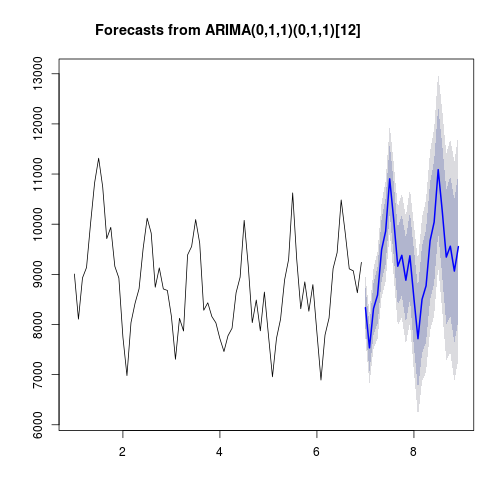

```r
q6 <- forecast(q6D1)
plot(q6)
```

#### 7. Using your model from In-class Ex2-#3, (ARIMA(p,0,q)x(P,1,Q)12 model), predict twelve months ahead in D1.

```r
(q7D1 <- auto.arima(D1, d = 0, D = 1))
```

```
## Series: D1
## ARIMA(2,0,0)(1,1,0)[12] with drift
##
## Coefficients:
##         ar1    ar2    sar1   drift
##       0.592  0.258  -0.350  -13.71
## s.e.  0.138  0.143   0.142   18.56
##
## sigma^2 estimated as 138798:  log likelihood=-348
## AIC=705.9   AICc=707   BIC=716.4
```

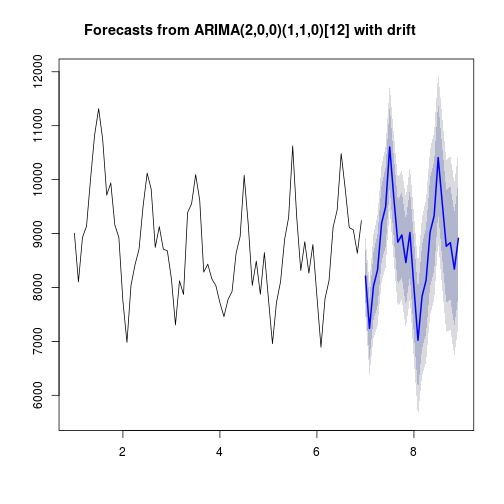

```r
q7 <- forecast(q7D1)
plot(q7)
```

#### 8. Compare your prediction from #5, #6, and #7. Plot the one-month predictions on the sampe plot. Which one do you like the best?

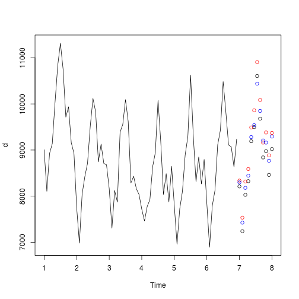

```r
plot(D1, xlim = c(1, 8))
points(x = seq(7, 8, length.out = 12), y = q7$mean[1:12])
points(x = seq(7, 8, length.out = 12), y = q6$mean[1:12], col = "red")
points(x = seq(7, 8, length.out = 12), y = q5$mean[1:12], col = "blue")
```